# exampleMetaprofile

author: “J. Attig”

08/11/2017

# 1 Conceptualisation

This script gives an example for using the createMetaprofilebyGRangeOverlaps function written by F. Agostini. The function is an effective way of summarising overlapping GenomicFeatures, with the primary goal to create Metaprofiles. The example shows the positioning of Alu and LINE repeat sequences relative to the splice sites of Alu and LINE-derived exons.

# 2 required packages

We need a few packages to run the code. Please ensure these are installed (install.packages()). If at any point R returns an error such as ‘No documentation for ‘melt.data.table’ in specified packages and libraries: you could try ‘??melt.data.table’ ‘in all likelihood you are more up to date on running the respective package. In this case, identify what the new name of the function is and replace occurences in ’createMetaprofilebyGRangeOverlaps’.

My versions are: R version 3.3.2 (2016-10-31) data.table 1.10.4 rtracklayer 1.34.2

```r
print("Show us our current working directory (set as desired) and load packages")
getwd()

library(knitr)
require(rtracklayer)
require(GenomicRanges)
require(data.table)
require(ggplot2)
require("RColorBrewer")

hg19.seqinfo <- readRDS("seqinfo.hg19.rds")

#and a function ro reduce overlapping GRanges without loosing the mcol entry
source("../generalised-Rscripts/Reduce.overlapping.Ranges.R")
```

# 3 Input data:

## 3.1 exon coordinates

Let’s look at the import of the exons as a bedgraph (more or less straight from UCSC). This is a GRange. Lots more information can be stored with it though! (compare with the .rds exon file)

**minimal bedgraph**

```
## GRanges object with 8368 ranges and 1 metadata column:
##          seqnames               ranges strand |     score
##             <Rle>            <IRanges>  <Rle> | <numeric>
##      [1]     chr1     [764383, 764484]      + |         0
##      [2]     chr1     [788771, 794826]      + |         0
##      [3]     chr1     [995657, 995773]      + |         0
##      [4]     chr1     [995919, 996088]      + |         0
##      [5]     chr1     [996400, 996497]      + |         0
##      ...      ...                  ...    ... .       ...
##   [8364]     chrY [24028418, 24028529]      - |         0
##   [8365]     chrY [24051959, 24052070]      - |         0
##   [8366]     chrY [24219790, 24219905]      - |         0
##   [8367]     chrY [24316885, 24316996]      - |         0
##   [8368]     chrY [26085332, 26085467]      - |         0
##   -------
##   seqinfo: 93 sequences from hg19 genome
```

**preprocessed Exon GRange**

```
## GRanges object with 8368 ranges and 10 metadata columns:
##          seqnames               ranges strand | hg19.knownGene.name
##             <Rle>            <IRanges>  <Rle> |            <factor>
##      [1]     chr1     [764383, 764484]      + |          uc031pjj.1
##      [2]     chr1     [788771, 794826]      + |          uc001abp.2
##      [3]     chr1     [995657, 995773]      + |          uc009vjs.1
##      [4]     chr1     [995919, 996088]      + |          uc009vjs.1
##      [5]     chr1     [996400, 996497]      + |          uc009vjs.1
##      ...      ...                  ...    ... .                 ...
##   [8364]     chrY [24028418, 24028529]      - |          uc004fuu.3
##   [8365]     chrY [24051959, 24052070]      - |          uc010nxd.3
##   [8366]     chrY [24219790, 24219905]      - |          uc010nxe.1
##   [8367]     chrY [24316885, 24316996]      - |          uc022coh.1
##   [8368]     chrY [26085332, 26085467]      - |          uc004fvy.1
##            txStart     txEnd  cdsStart    cdsEnd exonCount geneSymbol
```

[output cut: 27 more lines]

## 3.2 repeats annotated by repeatMasker

Repeat annotation for your favourite genome is available from RepeatMasker (or UCSC). These are large files. For the sake of demonstration, the code contains download command for the file and how to generate a GRange from it - but the download isnt executed by default). You’d do this only once and save the GRange as an R formatted file (Rdata or RDS) for future reference.

```
## [1] "Total number of repeat elements of interest: 3367415"
```

```
## [1] "made up of"
```

```
##
##            DNA           DNA?           LINE Low_complexity            LTR
##         524553           4312        1569213         100017         741743
##           LTR?             RC            RC?     Retroposon            RNA
##           8420           1796            435           5565            730
##           rRNA      Satellite          scRNA  Simple_repeat           SINE
##           1766           6329           1861         679517        1806997
##          SINE?          snRNA         srpRNA           tRNA        Unknown
##              5           4380           1383           1997           6436
```

```r
flank.size = 3000

### GRanges input (currently) must have unique 'gene_id' column
myExons.gr$gene_id <- paste("ID", 1:length(myExons.gr))
myExons.gr$exontype <- ifelse(myExons.gr$antisenseAlu.exon, "antisenseAluExon",
                              ifelse(myExons.gr$LINE.exon, "LINEderExon", NA))



selectplusFlank.splice.site.3 <- function(gr) {
   #remove single exon genes
   gr <- gr [ gr$exonCount != 1 ]

   #remove first exons (no 3'SS)
   gr <- gr [ gr$exon.number != 1 ]

   #splice site position
   mcols(gr) <- mcols(gr) [ c("gene_id", "exontype")]  #deleting the mcols here will reduce the memory usage quite drastically
   gr$splicesiteType <- "splicesite3"

   exon3SS <- flank(gr, -1, start = TRUE)

   #remove duplicates
   exon3SS <- rm.identical.dupl.ranges(exon3SS)

   #flank into intron
   exon3SSflanked <- flank(exon3SS, flank.size, both=TRUE)

   #resize to only have 100nt into the exon
   exon3SSflanked <- resize(exon3SSflanked,  flank.size+101, fix='start')

   return(exon3SSflanked)
}


selectplusFlank.splice.site.5 <- function(gr) {

   #remove single exon genes
   gr <- gr [ gr$exonCount != 1 ]

   #remove last exons (no 5'SS)
   gr <- gr [ gr$exonCount != gr$exon.number ]

   #splice site position
   mcols(gr) <- mcols(gr) [ c("gene_id", "exontype")]  #deleting the mcols here will reduce the memory usage quite drastically
   gr$splicesiteType <- "splicesite5"
   exon5SS <- flank(gr, -1, start = FALSE)

   #remove duplicates
   exon5SS <- rm.identical.dupl.ranges(exon5SS)

   #flank into intron
   exon5SSflanked <- flank(exon5SS, flank.size, both=FALSE, start=FALSE)
   exon5SSflanked <- resize(exon5SSflanked,  flank.size+101, fix='end')

   return(exon5SSflanked)
}


splice.sites.flanked.3SS <- selectplusFlank.splice.site.3(myExons.gr)
splice.sites.flanked.5SS <- selectplusFlank.splice.site.5(myExons.gr)
```

# 4 Metaprofile using repeat-coverage and flanked splice sites as input

```r
##### data.table profile based on RLE coverage of genomic elements
pos.covList <- lapply(repeats.reduced.grl, function(x) { x <- x [ strand(x) == "+"]; return(coverage(x))})
neg.covList <- lapply(repeats.reduced.grl, function(x) { x <- x [ strand(x) == "-"]; return(coverage(x))})



##### calculate densities around exons
source("../generalised-Rscripts/createMetaprofilebyGRangeOverlaps_20171002.R")



### for LINEs, we are interested in sense and antisense coverage, so we generate two profiles
### for Alus, we know only antisense Alus seed exons (efficiently); so we only look at the antisense
### we do the splice sites separately.
# This is not strictly necessary, the only difference will be the x-axis labels (from -5000 to +100 vs -100 to +5000)
# if done together in one GRange, gene_id must still be unique and x-axis labels have to be overwritten appropriately at the end in the plot


LINE.index <- grepl("LINE", names(pos.covList))
senseOrientation.3SSprofile.dt =  createProfile(pos.covList [ LINE.index ], neg.covList [ LINE.index ],
                            splice.sites.flanked.3SS,
                            sizeFac=NULL, upstream=flank.size, downstream=101,
                                             bin_width=40, min_count=1, keys=c("splicesiteType", "exontype"))

senseOrientation.5SSprofile.dt =  createProfile(pos.covList [ LINE.index ], neg.covList [ LINE.index ],
                            splice.sites.flanked.5SS,
                            sizeFac=NULL, upstream=101, downstream=flank.size,
                                             bin_width=40, min_count=1, keys=c("splicesiteType", "exontype"))

### to obtain the antisense coverage, we swap the positive and negative strand of the exon GRange (see ?invertStrand)
# (so minus strand repeat entries will be tested against plus strand exons )
# if we do this, we'll need to correct the labels
# alternatively: swap the strands in repeatsofInterest.gr and create coverage objects separately for antisense

antisenseOrientation.3SSprofile.dt =  createProfile(
                           pos.covList, neg.covList,
                           invertStrand(splice.sites.flanked.3SS),
                           revLabels = TRUE,
                           sizeFac=NULL, upstream=flank.size, downstream=101,
                           bin_width=40, min_count=1, keys=c("splicesiteType", "exontype"))

antisenseOrientation.5SSprofile.dt = createProfile(
                           pos.covList, neg.covList,
                           invertStrand(splice.sites.flanked.5SS),
                           revLabels = TRUE,
                           sizeFac=NULL, upstream=101, downstream=flank.size,
                           bin_width=40, min_count=1, keys=c("splicesiteType", "exontype"))
```

## 4.1 process primary output of metaprofile and plot with ggplot2

If there was any repeat family which didn’t have any overlaps with the input, than they are kicket out here (for instance, the ‘Jockeys’) The numbers refer to the number of bins with an entry for each family.

```
##            repFamily
## orientation LINE/CR1 LINE/L1 LINE/L2 LINE/Penelope LINE/RTE-BovB
##   antisense      308     308     308            77           308
##   sense          308     308     308             0           308
##            repFamily
## orientation LINE/RTE-X SINE/5S-Deu-L2 SINE/Alu SINE/MIR
##   antisense        308            154      308      308
##   sense            308              0        0        0
```

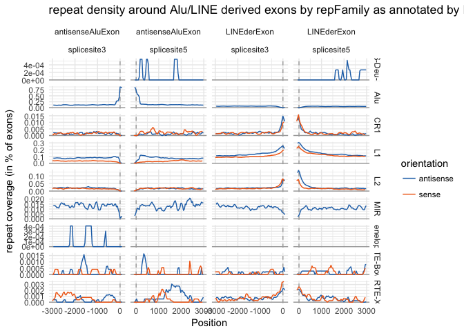

**Note the difference in the scales for Alu and LINE-repeats. Alus usually donate both 5’ and 3’ splice sites, while LINEs have a fair share of exons for which they only the 5’ splice site**

We also often want to table the number of repeat elements or the number of splice sites which are going into the plot

**Number of 5’ and 3’ splice sites in this dataset**

```
##    splicesiteType    N
## 1:    splicesite3 7356
## 2:    splicesite5 5581
```

**Number of repeat elements in each group**

|  | name | elements |
| --- | --- | --- |
| LINE/CR1 | LINE/CR1 | 67358 |
| LINE/Dong-R4 | LINE/Dong-R4 | 550 |
| LINE/Jockey | LINE/Jockey | 221 |
| LINE/L1 | LINE/L1 | 851306 |
| LINE/L1-Tx1 | LINE/L1-Tx1 | 189 |
| LINE/L2 | LINE/L2 | 504674 |
| LINE/Penelope | LINE/Penelope | 1086 |
| LINE/RTE-BovB | LINE/RTE-BovB | 8828 |
| LINE/RTE-X | LINE/RTE-X | 15300 |
| SINE/5S-Deu-L2 | SINE/5S-Deu-L2 | 2601 |
| SINE/Alu | SINE/Alu | 1119468 |
| SINE/MIR | SINE/MIR | 589339 |